# Implementación de indicadores

[figure not shown]

[figure not shown]

## Sinopsis

Es una breve descripción del flujo de las funciones para realizar backtesting apartir de una estrategia. Y el uso de estos.

### Estrategia

Se considera una estrategía como una combinación de indicadores y reglas para generar señales para entrar y salir de transacciones. La idea detras de esto se presenta en la siguiente grafica:

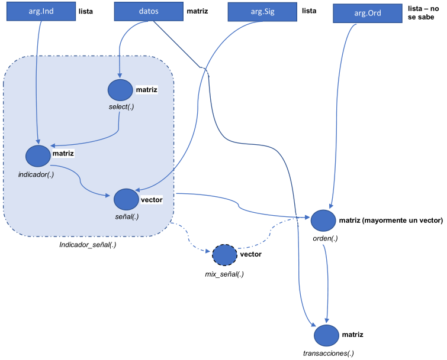

Esto permite realizar distintas modificaciones a la estrategía:

- Si se desea realizar una estrategía con mas de un indicador-señal, entonces se puede generar varias señales y luego con algúna función combinarlas para convertirla en una señal.
- Cambiar la función que genera las ordenes,

Se busca describir el flujo de las funciones para generar backtesting de diferentes estrategias, apartir de indicadores. Y el uso de este.

purrr enhances R’s functional programming (FP) toolkit by providing a complete and consistent set of tools for working with functions and vectors. If you’ve never heard of FP before, the best place to start is the family of `map()` functions which allow you to replace many for loops with code that is both more succinct and easier to read. The best place to learn about the `map()` functions is the [iteration chapter](http://r4ds.had.co.nz/iteration.html) in R for data science.

## Installation

```r
# The easiest way to get purrr is to install the whole tidyverse:
install.packages("tidyverse")
# Alternatively, install just purrr:
install.packages("purrr")
# Or the the development version from GitHub:
# install.packages("devtools")
devtools::install_github("tidyverse/purrr")
```

## Usage

The following example uses purrr to solve a fairly realistic problem: split a data frame into pieces, fit a model to each piece, compute the summary, then extract the R<sup>2</sup>.

```r
library(purrr)
mtcars %>%
  split(.$cyl) %>% # from base R
  map(~ lm(mpg ~ wt, data = .)) %>%
  map(summary) %>%
  map_dbl("r.squared")
```

```
##         4         6         8
## 0.5086326 0.4645102 0.4229655
```

This example illustrates some of the advantages of purrr functions over the equivalents in base R:

- The first argument is always the data, so purrr works naturally with the pipe.
- All purrr functions are type-stable. They always return the advertised output type (`map()` returns lists; `map_dbl()` returns double vectors), or they throw an error.
- All `map()` functions either accept function, formulas (used for succinctly generating anonymous functions), a character vector (used to extract components by name), or a numeric vector (used to extract by position).

## Code of conduct

Please note that this project is released with a Contributor Code of Conduct. By participating in this project you agree to abide by its terms.